# Differences Between Defaulted and Completed Loans

## by Ahmed Khalifa

## Investigation Overview

> The main goal of this investigation is to figure out the characteristics that differentiate completed from defaulted loans, to be able to better predict the outcome of a loan.

## Dataset Overview

> The dataset contains a large number of entries of different loans, with a wide variety of fata about each one, ranging from data about the loanee to data about the loan itself.

## Defaulted Vs. Completed Loans Count

> In this bar chart, we can see that a significant portion of loans are defaulted, which is a problem that needs to be mitigated.

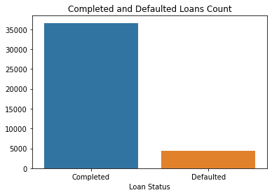

## Loan Term

> We can notice for the pie charts that ones(12-month term) are the most likely to be completed by a siginifcant margin.

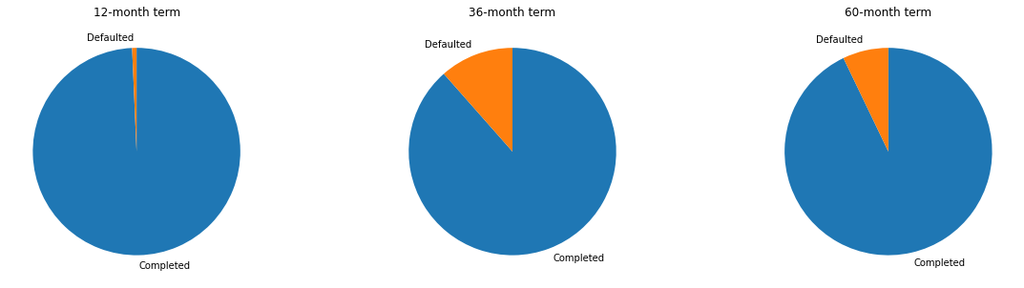

## Interest Rate

> We can notice from the two graphs that defaulted loans tend to have a higher interest rate, which is very logical. The higher interest rate will definitely make repaying the loan harder.

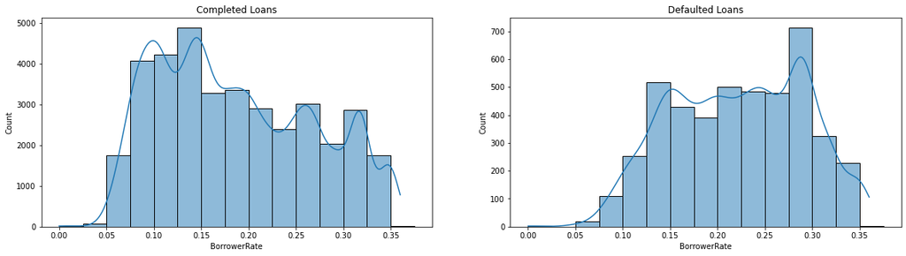

## Credit Score

> We can notice from the graph that loanees with higher credit score are morelikely to complete their loans.

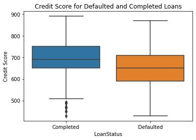